# 22521658-BTTuan3(5)

```python
%matplotlib inline
import matplotlib.pyplot as plt
import numpy as np
import pandas as pd
import seaborn as sns

from sklearn.model_selection import train_test_split
from sklearn import tree
from sklearn.naive_bayes import GaussianNB
from sklearn import metrics
```

```python
df = pd.read_csv('heart.csv')
```

```python
df.info()
```

```
<class 'pandas.core.frame.DataFrame'>
RangeIndex: 303 entries, 0 to 302
Data columns (total 14 columns):
 #   Column    Non-Null Count  Dtype
---  ------    --------------  -----
 0   age       303 non-null    int64
 1   sex       303 non-null    int64
 2   cp        303 non-null    int64
 3   trestbps  303 non-null    int64
 4   chol      303 non-null    int64
 5   fbs       303 non-null    int64
 6   restecg   303 non-null    int64
 7   thalach   303 non-null    int64
 8   exang     303 non-null    int64
 9   oldpeak   303 non-null    float64
 10  slope     303 non-null    int64
 11  ca        303 non-null    int64
 12  thal      303 non-null    int64
 13  target    303 non-null    int64
dtypes: float64(1), int64(13)
memory usage: 33.3 KB
```

```python
df.column=['age','sex','chest_pain_type','resting_blood_pressure','cholesterol','fasting_blood_sugar','rest_ecg','max_heart_rate_achieved',
           'exercise_induced_angina','st_depression','st_slope','num_major_vessels','thalassemia','target']
```

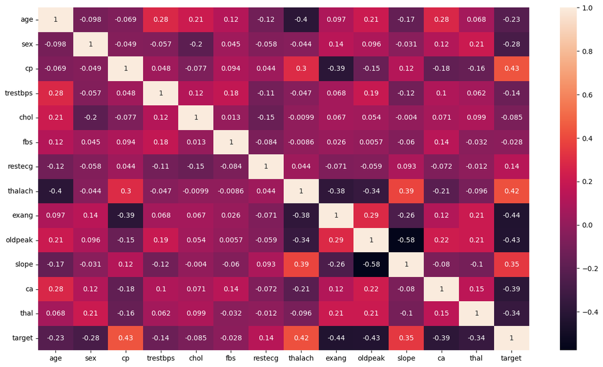

```python
plt.figure(figsize=(16,9))
sns.heatmap(df.corr(method='pearson'), annot=True)
plt.show()
```

```python
feature = df.drop('target', axis=1)
label = df['target']
```

```python
X_train, X_test, y_train, y_test = train_test_split(feature, label, test_size=0.3, random_state=42)
```

```python
clf = tree.DecisionTreeClassifier(criterion="entropy", random_state=0)
clf.fit(X_train, y_train)
```

```
DecisionTreeClassifier(criterion='entropy', random_state=0)
```

```python
tree_pred = clf.predict(X_test)

tree_score = metrics.accuracy_score(y_test, tree_pred)
print("Accuracy:", tree_score)
print("Report:", metrics.classification_report(y_test, tree_pred))
```

```
Accuracy: 0.7252747252747253
Report:               precision    recall  f1-score   support

           0       0.67      0.76      0.71        41
           1       0.78      0.70      0.74        50

    accuracy                           0.73        91
   macro avg       0.73      0.73      0.72        91
weighted avg       0.73      0.73      0.73        91
```

```python
tree_cm = metrics.confusion_matrix(y_test, tree_pred)
```

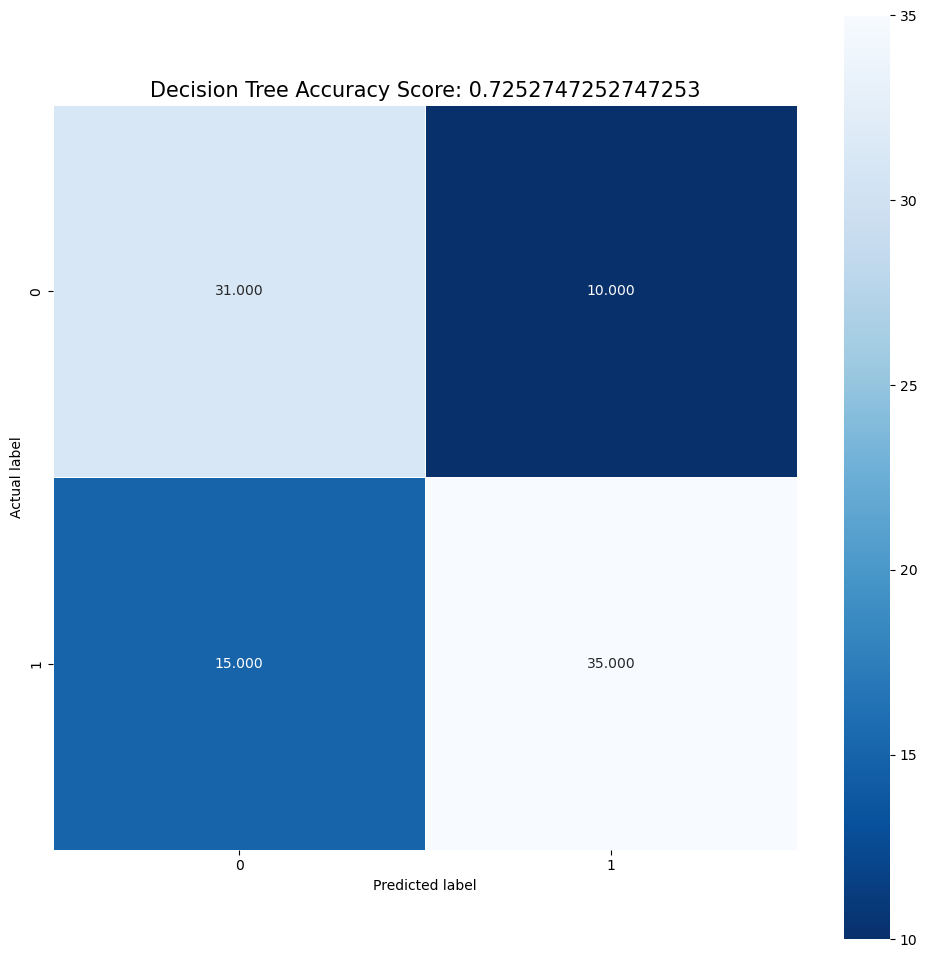

```python
plt.figure(figsize=(12,12))
sns.heatmap(tree_cm, annot=True, fmt=".3f", linewidths=.5, square = True, cmap = 'Blues_r');
plt.ylabel('Actual label');
plt.xlabel('Predicted label');
title = 'Decision Tree Accuracy Score: {0}'.format(tree_score)
plt.title(title, size = 15);
plt.show()
```

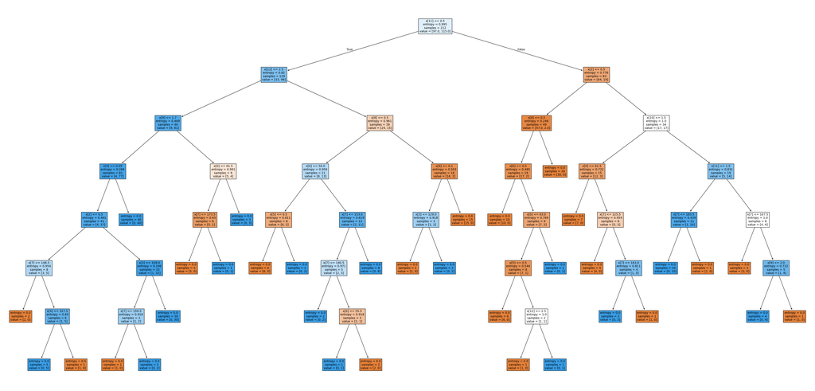

```python
fig, ax = plt.subplots(figsize=(50,24))
tree.plot_tree(clf, filled=True, fontsize=10)
plt.savefig('decision_tree', dpi=100)
plt.show()
```

```python
clf = tree.DecisionTreeClassifier(criterion="gini", random_state=0)
clf.fit(X_train, y_train)
```

```
DecisionTreeClassifier(random_state=0)
```

```python
tree_pred = clf.predict(X_test)

tree_score = metrics.accuracy_score(y_test, tree_pred)
print("Accuracy:", tree_score)
print("Report:", metrics.classification_report(y_test, tree_pred))
```

```
Accuracy: 0.7252747252747253
Report:               precision    recall  f1-score   support

           0       0.67      0.76      0.71        41
           1       0.78      0.70      0.74        50

    accuracy                           0.73        91
   macro avg       0.73      0.73      0.72        91
weighted avg       0.73      0.73      0.73        91
```

```python
tree_cm = metrics.confusion_matrix(y_test, tree_pred)
```

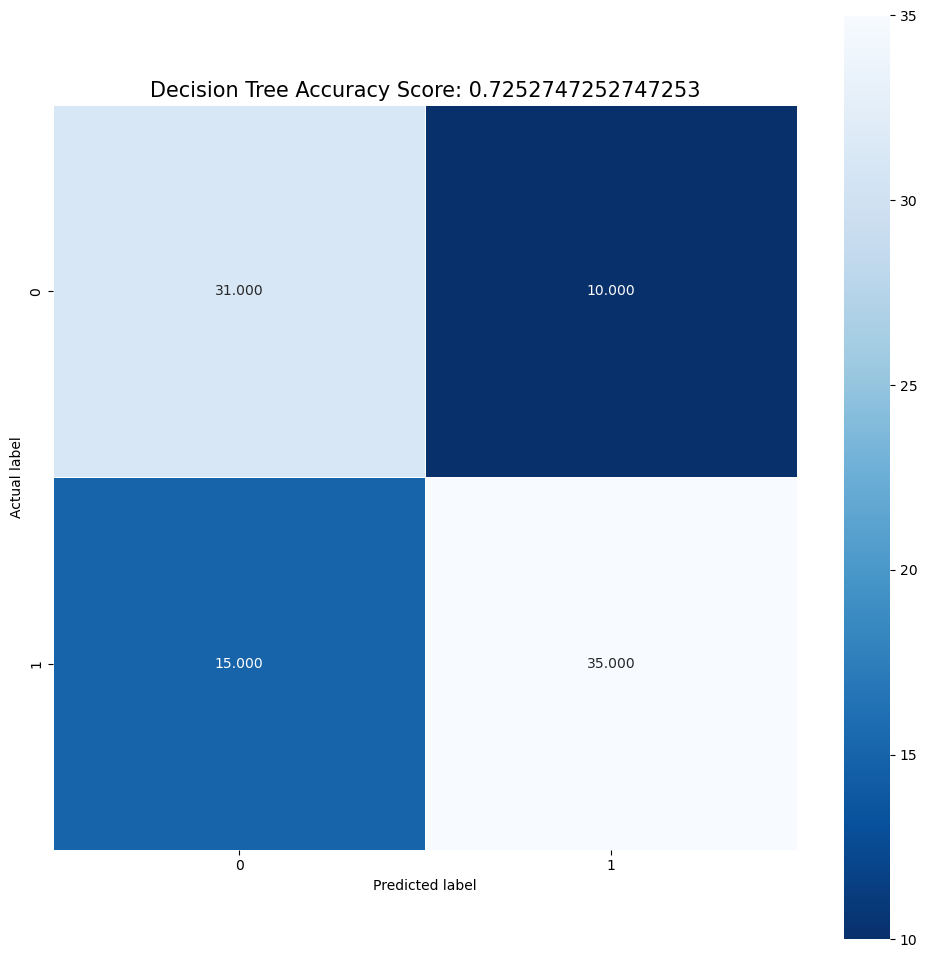

```python
plt.figure(figsize=(12,12))
sns.heatmap(tree_cm, annot=True, fmt=".3f", linewidths=.5, square = True, cmap = 'Blues_r');
plt.ylabel('Actual label');
plt.xlabel('Predicted label');
title = 'Decision Tree Accuracy Score: {0}'.format(tree_score)
plt.title(title, size = 15);
plt.show()
```

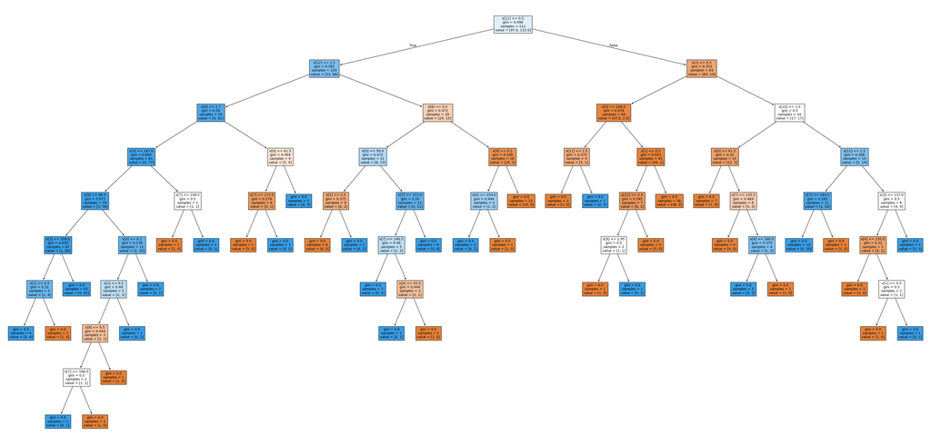

```python
fig, ax = plt.subplots(figsize=(50,24))
tree.plot_tree(clf, filled=True, fontsize=10)
plt.savefig('decision_tree', dpi=100)
plt.show()
```

```python
gnb = GaussianNB()
bayes_pred = gnb.fit(X_train, y_train).predict(X_test)

#Tinh toan cac gia tri cua mo hinh
bayes_score = metrics.accuracy_score(y_test, bayes_pred)
print("Accuracy:", bayes_score)
print("Report:", metrics.classification_report(y_test, bayes_pred))
```

```
Accuracy: 0.8351648351648352
Report:               precision    recall  f1-score   support

           0       0.78      0.88      0.83        41
           1       0.89      0.80      0.84        50

    accuracy                           0.84        91
   macro avg       0.84      0.84      0.83        91
weighted avg       0.84      0.84      0.84        91
```

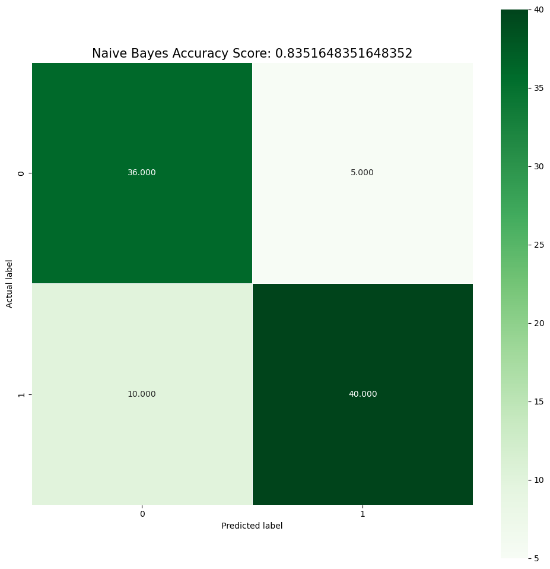

```python
bayes_cm = metrics.confusion_matrix(y_test, bayes_pred)
plt.figure(figsize=(12,12))
sns.heatmap(bayes_cm, annot=True, fmt=".3f", linewidths=.5, square = True, cmap = 'Greens');
plt.ylabel('Actual label');
plt.xlabel('Predicted label');
title = 'Naive Bayes Accuracy Score: {0}' .format(bayes_score)
plt.title(title, size = 15);
plt.show()
```

### Danh gia va nhan xet

#### Nhận xét

##### Decision Tree với Entropy:

Độ chính xác: 72.53% Cả hai lớp (0 và 1) đều có F1-score khá ổn (0.71 cho lớp 0 và 0.74 cho lớp 1). Điều này cho thấy thuật toán này hoạt động khá tốt trên cả hai lớp. Độ chính xác và các chỉ số đánh giá trung bình đều đạt mức 0.73 => thuật toán hoạt động đồng đều trên cả hai lớp và không có sự thiên lệch đáng kể giữa chúng.

##### Decision Tree với Gini:

Độ chính xác: 72.53% Kết quả hoàn toàn giống với Entropy, với độ chính xác tổng thể là 72.53% và các chỉ số precision, recall, và F1-score cho từng lớp cũng tương đương. => Gini đều có hiệu quả tương đương khi phân loại dữ liệu trong trường hợp này.

##### Naive Bayes:

Độ chính xác: 83.52% Naive Bayes có độ chính xác cao nhất trong ba thuật toán với 83.52%. Precision, recall, và F1-score của các lớp cũng cao hơn so với hai thuật toán còn lại, với F1-score là 0.83 cho lớp 0 và 0.84 cho lớp 1. => Naive Bayes phù hợp với dữ liệu này hơn và có khả năng phân loại tốt hơn cho cả hai lớp.

#### Kết luận tổng quát

Naive Bayes là thuật toán tốt nhất trong ba thuật toán, với độ chính xác cao nhất (83.52%) và F1-score tốt nhất cho cả hai lớp. Decision Tree với Entropy và Gini có kết quả tương đương, với độ chính xác thấp hơn (72.53%) và F1-score cho từng lớp cũng thấp hơn so với Naive Bayes.

#### Trong trường hợp này thì thuật toán Navie Bayes tốt hơn Gini và Entropy